```python
pip install --upgrade scipy
```

```python
import pandas as pd
import numpy as np
import string
import nltk
from nltk.corpus import stopwords
from nltk.stem import WordNetLemmatizer, SnowballStemmer
from sklearn.feature_extraction.text import CountVectorizer
from sklearn.feature_extraction.text import TfidfVectorizer
from sklearn.model_selection import train_test_split
from sklearn.metrics import accuracy_score
from sklearn.naive_bayes import MultinomialNB
from gensim.parsing.preprocessing import PorterStemmer, remove_stopwords

nltk.download('stopwords')
nltk.download('punkt')
from nltk.stem import LancasterStemmer
lancaster=LancasterStemmer()

from nltk.stem.wordnet import WordNetLemmatizer
lmtzr = WordNetLemmatizer()
nltk.download('wordnet')

from collections import Counter
import matplotlib.pyplot as plt
```

### Dataset

Textual Dataset is classified the poem text into 4 genres -> Affection,Environment,Music and Death

Features :

- Poem : textual data
- Genre : classification of text into 4 type namely, Affection,Environment,Music and Death

```python
df = pd.read_csv('data.csv')
```

```python
df.info()
```

```
<class 'pandas.core.frame.DataFrame'>
RangeIndex: 990 entries, 0 to 989
Data columns (total 2 columns):
 #   Column  Non-Null Count  Dtype
---  ------  --------------  -----
 0   Genre   990 non-null    object
 1   Poem    987 non-null    object
dtypes: object(2)
memory usage: 15.6+ KB
```

```python
df.head()
```

|  | Genre | Poem |
| --- | --- | --- |
| 0 | Music | In the thick brushthey spend the... |
| 1 | Music | Storms are generous. ... |
| 2 | Music | —After Ana Mendieta Did you carry around the ... |
| 3 | Music | for Aja Sherrard at 20The portent may itself ... |
| 4 | Music | for Bob Marley, Bavaria, November 1980 Here i... |

```python
df.Genre.value_counts()
```

```
Genre
Environment    252
Music          250
Death          247
Affection      241
Name: count, dtype: int64
```

## SECTION B - 40 Marks

## 2. In the provided data.csv dataset, the poem textis classified into 4 genres namely -Affection, Environment, Music and Death. Use this dataset as provided in the notebook pandas DataFrame and considering Poem column as text column, write python code for below.

```python
# Finding Null value
(df.isnull().sum()/df.shape[0])*100
```

```
Genre    0.00000
Poem     0.30303
dtype: float64
```

```python
# removing null value
df.dropna(subset=["Poem", "Genre"], inplace=True)
```

```python
# Finding Null value
(df.isnull().sum()/df.shape[0])*100
```

```
Genre    0.0
Poem     0.0
dtype: float64
```

### 2.a. Clean the 'Poem' column as questioned below. ( 15 Marks)

- Convert to lower case. (Marks-5)
- Remove stop-words. (Marks-3)
- Remove punctuations (Marks-3)
- Perform Stemming (Marks - 3 )
- Perform Lemmatization (Marks - 3)

```python
# Initialize stemmer and lemmatizer
stemmer = PorterStemmer()
lemmatizer = WordNetLemmatizer()
```

### Part 1 :Tokenize

```python
# 1. Tokenize the text
def tokenize(text):
    return word_tokenize(text)
```

### Part 2 : Lower Case

```python
# 2. Convert to lower case
def to_lower(tokens):
    return [token.lower() for token in tokens]
```

### Part 3 : Removing Stopwords

```python
# 3. Remove stop-words
def remove_stopwords(tokens):
    stop_words = set(stopwords.words('english'))
    return [token for token in tokens if token not in stop_words]
```

#### Removing Punctuation

```python
# 4. Remove punctuation
def remove_punctuation(tokens):
    return [token for token in tokens if token not in string.punctuation]
```

### Part 4 : Stemming & Lemitization

#### Stemming

```python
# 5. Perform stemming
def stem_tokens(tokens):
    return [stemmer.stem(token) for token in tokens]
```

Lemmatization

```python
# 6. Perform lemmatization
def lemmatize_tokens(tokens):
    return [lemmatizer.lemmatize(token) for token in tokens]
```

```python
# Function to apply all processing steps
def process_text(text):
    tokens = tokenize(text)
    tokens = to_lower(tokens)
    tokens = remove_stopwords(tokens)
    tokens = remove_punctuation(tokens)
    tokens = stem_tokens(tokens)
    tokens = lemmatize_tokens(tokens)
    return ' '.join(tokens)
```

```python
from nltk.tokenize import word_tokenize
# Apply the processing function to each poem
df['Processed_Poem'] = df['Poem'].apply(process_text)

# Show the processed DataFrame
print(df[['Poem', 'Processed_Poem']])
```

```
                                                  Poem  \
0                  In the thick brushthey spend the...
1       Storms are generous.                       ...
2     —After Ana Mendieta Did you carry around the ...
3     for Aja Sherrard at 20The portent may itself ...
4     for Bob Marley, Bavaria, November 1980 Here i...
..                                                 ...
985  To pick a tulip from the garden, the red one. ...
986  We are as clouds that veil the midnight moon; ...
987  When pulled, the spider web took another form....
988  Whose woods these are I think I know. His hous...
989  you can make the maples blazejust by stopping ...

                                        Processed_Poem
0    thick brushthei spend hottest part dai soak ho...
1    storm gener someth easi surrend sit window ste...
2    —after ana mendieta carri around matin star ho...
3    aja sherrard 20the portent mai memori —wallac ...
4    bob marlei bavaria novemb 1980 brilliant morn ...
..                                                 ...
985  pick tulip garden red on put desk small blue v...
986  cloud veil midnight moon restlessli speed glea...
987  pull spider web took anoth form.th bull ’ s-ey...
988           whose wood think know hous villag though
989  make mapl blazejust stop look set clock barkso...

[987 rows x 2 columns]
```

### 2.b Which words in the original 'Poem' column have the highest frequency of repetition, and what is their percentage relative to the total word count? (10 marks)

```python
# Calculate the total number of words

# Find the most repeated words

# Calculate the percentage of each repeated word relative to the total word count

# Display the results
print("Top 10 repeated words and their percentages in 'Poem':")

# Visualize the data
```

```
Top 10 repeated words and their percentages in 'Poem':
```

```
Top 10 repeated words and their percentages in 'Poem' (excluding stop-words and punctuation):
Word: 'like', Count: 188, Percentage: 0.73%
Word: 'love', Count: 164, Percentage: 0.64%
Word: 'one', Count: 148, Percentage: 0.57%
Word: 's', Count: 119, Percentage: 0.46%
Word: 'night', Count: 92, Percentage: 0.36%
Word: 'day', Count: 79, Percentage: 0.31%
Word: 'us', Count: 77, Percentage: 0.30%
Word: 'white', Count: 74, Percentage: 0.29%
Word: 'would', Count: 73, Percentage: 0.28%
Word: 'see', Count: 72, Percentage: 0.28%
```

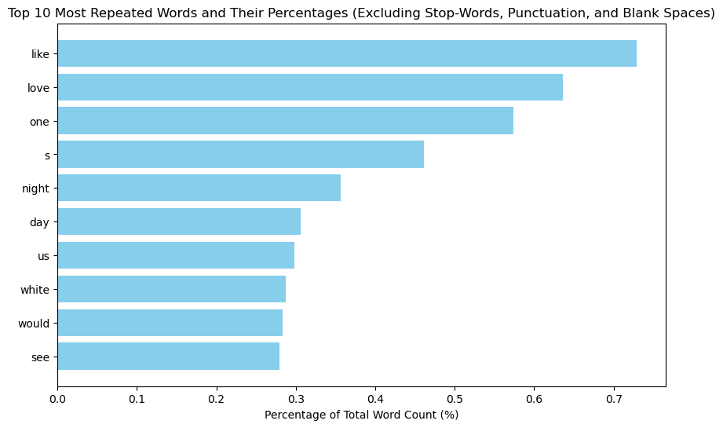

```python
import pandas as pd
from collections import Counter
import string
import nltk
import re
from nltk.corpus import stopwords
from nltk.tokenize import word_tokenize
import matplotlib.pyplot as plt

# Download necessary NLTK resources
#nltk.download('punkt')
#nltk.download('stopwords')



# Initialize the set of stop words
stop_words = set(stopwords.words('english'))

# Tokenization, lowercasing, and stop-word removal function with punctuation and apostrophe removal
def tokenize_and_lower(text):
    # Tokenize and convert to lower case
    tokens = word_tokenize(text)
    # Remove stop words, punctuation (including apostrophes), and blank spaces, and convert to lowercase
    tokens = [
        re.sub(r"[^\w\s]", "", token.lower())  # Remove all punctuation (including apostrophes)
        for token in tokens
        if token.lower() not in stop_words and token not in string.punctuation and token.strip() != ""
    ]
    return tokens

# Apply the function to all poems
all_tokens = []
for poem in df['Poem']:
    all_tokens.extend(tokenize_and_lower(poem))

# Filter out empty strings from tokens
all_tokens = [token for token in all_tokens if token != ""]

# Calculate the total word count
total_word_count = len(all_tokens)

# Find the most common words
word_counts = Counter(all_tokens)
most_common_words = word_counts.most_common()

# Calculate the percentage of each word relative to the total word count
word_percentages = [(word, count, (count / total_word_count) * 100) for word, count in most_common_words]

# Display the top 10 repeated words and their percentages
print("Top 10 repeated words and their percentages in 'Poem' (excluding stop-words and punctuation):")
for word, count, percentage in word_percentages[:10]:
    print(f"Word: '{word}', Count: {count}, Percentage: {percentage:.2f}%")

# Visualize the top 10 most common words and their percentages
top_10_words = word_percentages[:10]
words, counts, percentages = zip(*top_10_words)

# Plotting the data
plt.figure(figsize=(10, 6))
plt.barh(words, percentages, color='skyblue')
plt.xlabel('Percentage of Total Word Count (%)')
plt.title('Top 10 Most Repeated Words and Their Percentages (Excluding Stop-Words, Punctuation, and Blank Spaces)')
plt.gca().invert_yaxis()
plt.show()
```

### 2.c What is the average sentence length in terms of words in the 'Poem' column? (5 marks)

```python
# Calculate the sentence lengths

# Calculate the average sentence length
```

```python
import pandas as pd
import nltk
from nltk.tokenize import sent_tokenize, word_tokenize


# Function to calculate the sentence lengths (in terms of word count)
def calculate_sentence_lengths(text):
    # Split the text into sentences
    sentences = sent_tokenize(text)

    # Calculate the number of words in each sentence
    sentence_lengths = [len(word_tokenize(sentence)) for sentence in sentences]

    return sentence_lengths

# Apply the function to the 'Poem' column to get sentence lengths
df['Sentence Lengths'] = df['Poem'].apply(calculate_sentence_lengths)

# Calculate the average sentence length for each poem
df['Average Sentence Length'] = df['Sentence Lengths'].apply(lambda x: sum(x) / len(x) if len(x) > 0 else 0)

# Calculate the overall average sentence length across all poems
overall_average_length = df['Average Sentence Length'].mean()

# Display the sentence lengths for each poem and the overall average sentence length



print(f"\nOverall average sentence length across all poems: {overall_average_length:.2f}")
print("Sentence lengths for each poem:")
df[['Poem', 'Sentence Lengths', 'Average Sentence Length']]
```

```
Overall average sentence length across all poems: 33.54
Sentence lengths for each poem:
```

|  | Poem | Sentence Lengths | Average Sentence Length |
| --- | --- | --- | --- |
| 0 | In the thick brushthey spend the... | [28] | 28.000000 |
| 1 | Storms are generous. ... | [4, 26] | 15.000000 |
| 2 | —After Ana Mendieta Did you carry around the ... | [11, 8, 11, 17] | 11.750000 |
| 3 | for Aja Sherrard at 20The portent may itself ... | [11, 27, 3] | 13.666667 |
| 4 | for Bob Marley, Bavaria, November 1980 Here i... | [42] | 42.000000 |
| ... | ... | ... | ... |
| 985 | To pick a tulip from the garden, the red one. ... | [12, 14, 23, 4] | 13.250000 |
| 986 | We are as clouds that veil the midnight moon; ... | [60] | 60.000000 |
| 987 | When pulled, the spider web took another form.... | [40, 11, 8] | 19.666667 |
| 988 | Whose woods these are I think I know. His hous... | [9, 7] | 8.000000 |
| 989 | you can make the maples blazejust by stopping ... | [21, 28] | 24.500000 |

987 rows × 3 columns

### 2.d What are the unique word counts in the 'Poem' column, and how many words appear only once? ( 5 marks)

```python
# Count unique words
```

```python
# Initialize the set of stop words
stop_words = set(nltk.corpus.stopwords.words('english'))

# Tokenization and stop-word removal function with punctuation removal
def tokenize_and_lower(text):
    # Tokenize and convert to lower case
    tokens = word_tokenize(text)
    # Remove stop words, punctuation (including apostrophes), and convert to lowercase
    tokens = [
        re.sub(r"[^\w\s]", "", token.lower())  # Remove all punctuation (including apostrophes)
        for token in tokens
        if token.lower() not in stop_words and token not in string.punctuation and token.strip() != ""
    ]
    return tokens

# Apply the function to all poems
all_tokens = []
for poem in df['Poem']:
    all_tokens.extend(tokenize_and_lower(poem))

# Count the occurrences of each word
word_counts = Counter(all_tokens)

# Calculate the number of unique words
unique_word_count = len(word_counts)

# Identify words that appear only once
words_once = [word for word, count in word_counts.items() if count == 1]
words_once_count = len(words_once)

# Display the results
print(f"Total number of unique words: {unique_word_count}")
print(f"Number of words that appear only once: {words_once_count}")
```

```
Total number of unique words: 9721
Number of words that appear only once: 6398
```

### 2.e. What is the distribution of word lengths in the 'Poem' column? ( 5 marks)

```python
# Calculate word lengths

# Count the frequency of each word length

# Sort by word length

# Display the distribution

# Plot the distribution
```

```
Word length distribution:
Word length 1: 2933 words
Word length 2: 7280 words
Word length 3: 9826 words
Word length 4: 9000 words
Word length 5: 6061 words
Word length 6: 4205 words
Word length 7: 3200 words
Word length 8: 1965 words
Word length 9: 1280 words
Word length 10: 729 words
Word length 11: 456 words
Word length 12: 264 words
Word length 13: 172 words
Word length 14: 100 words
Word length 15: 60 words
Word length 16: 53 words
Word length 17: 29 words
Word length 18: 22 words
Word length 19: 19 words
Word length 20: 5 words
Word length 21: 3 words
Word length 22: 1 words
Word length 25: 1 words
```

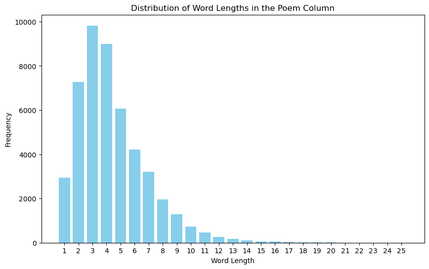

```python
import pandas as pd
import nltk
from nltk.tokenize import word_tokenize
from collections import Counter
import string
import re
import matplotlib.pyplot as plt



# Tokenization and preprocessing function
def tokenize_and_clean(text):
    # Tokenize and convert to lower case
    tokens = word_tokenize(text)
    # Remove punctuation, stop words, and whitespace-only tokens
    cleaned_tokens = [
        re.sub(r"[^\w\s]", "", token.lower())  # Remove all punctuation
        for token in tokens
        if token.strip() != ""  # Remove empty tokens
    ]
    return cleaned_tokens

# Apply the function to all poems and get all tokens
all_tokens = []
for poem in df['Poem']:
    all_tokens.extend(tokenize_and_clean(poem))

# Calculate the length of each word
word_lengths = [len(word) for word in all_tokens if len(word) > 0]

# Count the frequency of each word length
length_counts = Counter(word_lengths)

# Sort by word length
sorted_length_counts = dict(sorted(length_counts.items()))

# Display the distribution
print("Word length distribution:")
for length, count in sorted_length_counts.items():
    print(f"Word length {length}: {count} words")

# Plot the distribution
plt.figure(figsize=(10, 6))
plt.bar(sorted_length_counts.keys(), sorted_length_counts.values(), color='skyblue')
plt.xlabel('Word Length')
plt.ylabel('Frequency')
plt.title('Distribution of Word Lengths in the Poem Column')
plt.xticks(range(1, max(sorted_length_counts.keys()) + 1))
plt.show()
```

## Section C

Use the original dataFrame in order to build ML model as questioned below.

```python
df.head(20)
```

|  | Genre | Poem | Processed_Poem | Sentence Lengths | Average Sentence Length |
| --- | --- | --- | --- | --- | --- |
| 0 | Music | In the thick brushthey spend the... | thick brushthei spend hottest part dai soak ho... | [28] | 28.000000 |
| 1 | Music | Storms are generous. ... | storm gener someth easi surrend sit window ste... | [4, 26] | 15.000000 |
| 2 | Music | —After Ana Mendieta Did you carry around the ... | —after ana mendieta carri around matin star ho... | [11, 8, 11, 17] | 11.750000 |
| 3 | Music | for Aja Sherrard at 20The portent may itself ... | aja sherrard 20the portent mai memori —wallac ... | [11, 27, 3] | 13.666667 |
| 4 | Music | for Bob Marley, Bavaria, November 1980 Here i... | bob marlei bavaria novemb 1980 brilliant morn ... | [42] | 42.000000 |
| 5 | Music | For Frank X WalkerFXW: I don’t know how to sw... | frank x walkerfxw ’ know swim fxw pool black f... | [18, 33, 6] | 19.000000 |
| 6 | Music | My neighbor to the left had a stroke a couple... | neighbor left stroke coupl year ago ’ look lik... | [13, 19, 10] | 14.000000 |
| 7 | Music | —for a sixty-seven-pound nugget of Lake Superi... | —for sixty-seven-pound nugget lake superior co... | [42] | 42.000000 |
| 8 | Music | —Issa Rae Everybody Black is my hometown team.... | —issa rae everybodi black hometown team everyb... | [9, 11, 12, 7] | 9.750000 |
| 9 | Music | "Save your hands,” my mother says, seeing me u... | `` save hand ” mother sai see untwist jar 's t... | [53, 16, 2] | 23.666667 |
| 10 | Music | “It’s all empty, empty,”he said to himself. “T... | “ ’ empti empti ” said “ sex drug violenc espe... | [15, 6, 23, 10, 15, 3] | 12.000000 |
| 11 | Music | (for Ntozake Shange)I used to be a roller coas... | ntozak shang u roller coaster girl 7 time row ... | [29] | 29.000000 |
| 12 | Music | (the passports curled up) (it was so humid in ... | passport curl humid rent room travel forget cr... | [38] | 38.000000 |
| 13 | Music | {on the occasion of Martin Puryear’s Noblesse ... | occas martin puryear ’ noble ’ red cedar alumi... | [72] | 72.000000 |
| 14 | Music | 1 Muddled stillnessAll summer SunPunched the y... | 1 muddl stillnessal summer sunpunch yellow jac... | [37] | 37.000000 |
| 15 | Music | 1. lush field of shadows, static hush and radi... | 1. lush field shadow static hush radial itch p... | [14, 10, 8, 13] | 11.250000 |
| 16 | Music | 7. Letters arrived in intervals, as with every... | 7. letter arriv interv everyth el on might com... | [27, 6, 3, 7, 17] | 12.000000 |
| 17 | Music | A crocodile slips its earth-toned bodyback int... | crocodil slip earth-ton bodyback river silenc ... | [25, 5, 13, 15] | 14.500000 |
| 18 | Music | A long night I spent thinking that reality was... | long night spent think realiti stori human spe... | [61] | 61.000000 |
| 19 | Music | A man can’t die where there is no earth becaus... | man ’ die earth place buri bodi sky understand... | [21, 12, 20, 6] | 14.750000 |

### 3 a. Convert the 'Poem' column into numerical using Count-vectorization. (5 marks)

```python
import pandas as pd
from sklearn.feature_extraction.text import CountVectorizer

# Initialize CountVectorizer
vectorizer = CountVectorizer()

# Fit and transform the 'Poem' column
X = vectorizer.fit_transform(df['Poem'])
#X = vectorizer.fit_transform(df['Processed_Poem'])
# Create a DataFrame from the transformed data
df_count_vectorized = pd.DataFrame(X.toarray(), columns=vectorizer.get_feature_names_out())

# Display the resulting DataFrame
print("Count Vectorized DataFrame:")
df_count_vectorized.head()
```

```
Count Vectorized DataFrame:
```

|  | 00 | 000 | 10maggie | 12 | 13 | 15 | 1558 | 17 | 1865there | 1908 | ... | zenith | zephyrs | zest | zhashagiwag | zhingwaakwag | zipperedshut | zither | zithers | zoom | ȟe |
| --- | --- | --- | --- | --- | --- | --- | --- | --- | --- | --- | --- | --- | --- | --- | --- | --- | --- | --- | --- | --- | --- |
| 0 | 0 | 0 | 0 | 0 | 0 | 0 | 0 | 0 | 0 | 0 | ... | 0 | 0 | 0 | 0 | 0 | 0 | 0 | 0 | 0 | 0 |
| 1 | 0 | 0 | 0 | 0 | 0 | 0 | 0 | 0 | 0 | 0 | ... | 0 | 0 | 0 | 0 | 0 | 0 | 0 | 0 | 0 | 0 |
| 2 | 0 | 0 | 0 | 0 | 0 | 0 | 0 | 0 | 0 | 0 | ... | 0 | 0 | 0 | 0 | 0 | 0 | 0 | 0 | 0 | 0 |
| 3 | 0 | 0 | 0 | 0 | 0 | 0 | 0 | 0 | 0 | 0 | ... | 0 | 0 | 0 | 0 | 0 | 0 | 0 | 0 | 0 | 0 |
| 4 | 0 | 0 | 0 | 0 | 0 | 0 | 0 | 0 | 0 | 0 | ... | 0 | 0 | 0 | 0 | 0 | 0 | 0 | 0 | 0 | 0 |

5 rows × 9219 columns

### 3.b. Convert the text feature/column into numerical using TF-IDF (5-Marks)

```python
import pandas as pd
from sklearn.feature_extraction.text import TfidfVectorizer

# Initialize the TF-IDF Vectorizer
tfidf_vectorizer = TfidfVectorizer()

# Fit and transform the 'Poem' column
X_tfidf = tfidf_vectorizer.fit_transform(df['Poem'])

# Create a DataFrame from the transformed data
df_tfidf = pd.DataFrame(X_tfidf.toarray(), columns=tfidf_vectorizer.get_feature_names_out())

# Display the resulting DataFrame
print("TF-IDF Vectorized DataFrame:")
df_tfidf.head()
```

```
TF-IDF Vectorized DataFrame:
```

|  | 00 | 000 | 10maggie | 12 | 13 | 15 | 1558 | 17 | 1865there | 1908 | ... | zenith | zephyrs | zest | zhashagiwag | zhingwaakwag | zipperedshut | zither | zithers | zoom | ȟe |
| --- | --- | --- | --- | --- | --- | --- | --- | --- | --- | --- | --- | --- | --- | --- | --- | --- | --- | --- | --- | --- | --- |
| 0 | 0.0 | 0.0 | 0.0 | 0.0 | 0.0 | 0.0 | 0.0 | 0.0 | 0.0 | 0.0 | ... | 0.0 | 0.0 | 0.0 | 0.0 | 0.0 | 0.0 | 0.0 | 0.0 | 0.0 | 0.0 |
| 1 | 0.0 | 0.0 | 0.0 | 0.0 | 0.0 | 0.0 | 0.0 | 0.0 | 0.0 | 0.0 | ... | 0.0 | 0.0 | 0.0 | 0.0 | 0.0 | 0.0 | 0.0 | 0.0 | 0.0 | 0.0 |
| 2 | 0.0 | 0.0 | 0.0 | 0.0 | 0.0 | 0.0 | 0.0 | 0.0 | 0.0 | 0.0 | ... | 0.0 | 0.0 | 0.0 | 0.0 | 0.0 | 0.0 | 0.0 | 0.0 | 0.0 | 0.0 |
| 3 | 0.0 | 0.0 | 0.0 | 0.0 | 0.0 | 0.0 | 0.0 | 0.0 | 0.0 | 0.0 | ... | 0.0 | 0.0 | 0.0 | 0.0 | 0.0 | 0.0 | 0.0 | 0.0 | 0.0 | 0.0 |
| 4 | 0.0 | 0.0 | 0.0 | 0.0 | 0.0 | 0.0 | 0.0 | 0.0 | 0.0 | 0.0 | ... | 0.0 | 0.0 | 0.0 | 0.0 | 0.0 | 0.0 | 0.0 | 0.0 | 0.0 | 0.0 |

5 rows × 9219 columns

```python
#gem code

import pandas as pd
from sklearn.feature_extraction.text import TfidfVectorizer

# Assuming the DataFrame 'df' is already created

# Create a TfidfVectorizer object
vectorizer = TfidfVectorizer()

# Fit and transform the 'Poem' column
X_tfidf = vectorizer.fit_transform(df['Poem'])

# Print the shape of the TF-IDF matrix
print("Shape of TF-IDF matrix:", X_tfidf.shape)

# Get the vocabulary of TF-IDF
feature_names = vectorizer.get_feature_names_out()
print("\nVocabulary:\n", feature_names)
```

```
Shape of TF-IDF matrix: (987, 9219)

Vocabulary:
 ['00' '000' '10maggie' ... 'zithers' 'zoom' 'ȟe']
```

```python
df['Genre'].value_counts()
```

```
Genre
Environment    252
Music          250
Death          244
Affection      241
Name: count, dtype: int64
```

```python
def map_genre_to_value(genre):
    genre_mapping = {
        'Affection': 1,
        'Environment': 2,
        'Music': 3,
        'Death': 4
    }
    return genre_mapping.get(genre, None)  # Return None if the genre is not found

# Apply the function to the Genre column
df['Genre_Value'] = df['Genre'].apply(map_genre_to_value)
```

### 3.c. Split both Count-vectorirsed & TF-IDF dataset into train & test set with one fourth records being held for testing also ensure stratified sampling of traget i.e. ‘Genre’ on both splits ( 5-Marks)

```python
import pandas as pd
from sklearn.model_selection import train_test_split
from sklearn.feature_extraction.text import CountVectorizer, TfidfVectorizer

# Initialize the Count Vectorizer and TF-IDF Vectorizer
count_vectorizer = CountVectorizer()
tfidf_vectorizer = TfidfVectorizer()

# Apply Count Vectorizer to the 'Poem' column
X_count = count_vectorizer.fit_transform(df['Poem'])

# Apply TF-IDF Vectorizer to the 'Poem' column
X_tfidf = tfidf_vectorizer.fit_transform(df['Poem'])

# Extract target variable (Genre)
y = df['Genre']

# Split Count Vectorized Data (Stratified Sampling)
X_train_count, X_test_count, y_train_count, y_test_count = train_test_split(
    X_count, y, test_size=0.25, stratify=y, random_state=42
)

# Split TF-IDF Data (Stratified Sampling)
X_train_tfidf, X_test_tfidf, y_train_tfidf, y_test_tfidf = train_test_split(
    X_tfidf, y, test_size=0.25, stratify=y, random_state=42
)

# Display the shape of the resulting splits
print("Count Vectorizer - Training Set Shape:", X_train_count.shape)
print("Count Vectorizer - Test Set Shape:", X_test_count.shape)
print("TF-IDF - Training Set Shape:", X_train_tfidf.shape)
print("TF-IDF - Test Set Shape:", X_test_tfidf.shape)
```

```
Count Vectorizer - Training Set Shape: (740, 9219)
Count Vectorizer - Test Set Shape: (247, 9219)
TF-IDF - Training Set Shape: (740, 9219)
TF-IDF - Test Set Shape: (247, 9219)
```

```python
y_train_count
```

```
423          Death
691    Environment
629    Environment
735    Environment
48           Music
          ...
89           Music
177          Music
319          Death
665    Environment
534      Affection
Name: Genre, Length: 740, dtype: object
```

```python
df
```

|  | Genre | Poem | Processed_Poem | Sentence Lengths | Average Sentence Length | Genre_Value |
| --- | --- | --- | --- | --- | --- | --- |
| 0 | Music | In the thick brushthey spend the... | thick brushthei spend hottest part dai soak ho... | [28] | 28.000000 | 3 |
| 1 | Music | Storms are generous. ... | storm gener someth easi surrend sit window ste... | [4, 26] | 15.000000 | 3 |
| 2 | Music | —After Ana Mendieta Did you carry around the ... | —after ana mendieta carri around matin star ho... | [11, 8, 11, 17] | 11.750000 | 3 |
| 3 | Music | for Aja Sherrard at 20The portent may itself ... | aja sherrard 20the portent mai memori —wallac ... | [11, 27, 3] | 13.666667 | 3 |
| 4 | Music | for Bob Marley, Bavaria, November 1980 Here i... | bob marlei bavaria novemb 1980 brilliant morn ... | [42] | 42.000000 | 3 |
| ... | ... | ... | ... | ... | ... | ... |
| 985 | Environment | To pick a tulip from the garden, the red one. ... | pick tulip garden red on put desk small blue v... | [12, 14, 23, 4] | 13.250000 | 2 |
| 986 | Environment | We are as clouds that veil the midnight moon; ... | cloud veil midnight moon restlessli speed glea... | [60] | 60.000000 | 2 |
| 987 | Environment | When pulled, the spider web took another form.... | pull spider web took anoth form.th bull ’ s-ey... | [40, 11, 8] | 19.666667 | 2 |
| 988 | Environment | Whose woods these are I think I know. His hous... | whose wood think know hous villag though | [9, 7] | 8.000000 | 2 |
| 989 | Environment | you can make the maples blazejust by stopping ... | make mapl blazejust stop look set clock barkso... | [21, 28] | 24.500000 | 2 |

987 rows × 6 columns

```python
import pandas as pd
from sklearn.model_selection import train_test_split
from sklearn.feature_extraction.text import CountVectorizer, TfidfVectorizer

# Initialize the Count Vectorizer and TF-IDF Vectorizer
count_vectorizer = CountVectorizer()
tfidf_vectorizer = TfidfVectorizer()

# Apply Count Vectorizer to the 'Poem' column
X_count = count_vectorizer.fit_transform(df['Poem'])

# Apply TF-IDF Vectorizer to the 'Poem' column
X_tfidf = tfidf_vectorizer.fit_transform(df['Poem'])

# Extract target variable (Genre)
y = df['Genre_Value']

# Split Count Vectorized Data (Stratified Sampling)
X_train_count, X_test_count, y_train_count, y_test_count = train_test_split(
    X_count, y, test_size=0.25, stratify=y, random_state=42
)

# Split TF-IDF Data (Stratified Sampling)
X_train_tfidf, X_test_tfidf, y_train_tfidf, y_test_tfidf = train_test_split(
    X_tfidf, y, test_size=0.25, stratify=y, random_state=42
)

# Display the shape of the resulting splits
print("Count Vectorizer - Training Set Shape:", X_train_count.shape)
print("Count Vectorizer - Test Set Shape:", X_test_count.shape)
print("TF-IDF - Training Set Shape:", X_train_tfidf.shape)
print("TF-IDF - Test Set Shape:", X_test_tfidf.shape)
```

```
Count Vectorizer - Training Set Shape: (740, 9219)
Count Vectorizer - Test Set Shape: (247, 9219)
TF-IDF - Training Set Shape: (740, 9219)
TF-IDF - Test Set Shape: (247, 9219)
```

### 3.d. Build a basic Multinomial Naive Bayes classifier. on Count-vectorize train set. Find out its accuracy on Count-vectorize test set. (5+5)

```python
from sklearn.naive_bayes import MultinomialNB
from sklearn.metrics import accuracy_score

# Initialize the Multinomial Naive Bayes classifier
nb_classifier = MultinomialNB()

# Train the classifier on the Count-Vectorized training set
nb_classifier.fit(X_train_count, y_train_count)

# Predict the genre on the Count-Vectorized test set
y_pred_count = nb_classifier.predict(X_test_count)

# Calculate the accuracy of the model
accuracy_count = accuracy_score(y_test_count, y_pred_count)

# Display the accuracy
print(f"Accuracy on Count-Vectorized Test Set: {accuracy_count * 100:.2f}%")
```

```
Accuracy on Count-Vectorized Test Set: 37.25%
```

```python
y_train_count
```

[output not shown]

### 3.e. Build a basic Multinomial Naive Bayes classifier on TF-IDF train set. find out its accuracy on TF-IDF test set. Which model has better accuracy? (5+5)

```python
# Train the Multinomial Naive Bayes classifier on the TF-IDF train set
nb_classifier_tfidf = MultinomialNB()

# Train the classifier using the TF-IDF train set
nb_classifier_tfidf.fit(X_train_tfidf, y_train_tfidf)

# Predict the genre on the TF-IDF test set
y_pred_tfidf = nb_classifier_tfidf.predict(X_test_tfidf)

# Calculate the accuracy on the TF-IDF test set
accuracy_tfidf = accuracy_score(y_test_tfidf, y_pred_tfidf)



# Compare the accuracy of both models
print(f"Accuracy on Count-Vectorized Test Set: {accuracy_count * 100:.2f}%")
print(f"Accuracy on TF-IDF Test Set: {accuracy_tfidf * 100:.2f}%")

if accuracy_count > accuracy_tfidf:
    print("Count-Vectorized model has better accuracy.")
else:
    print("TF-IDF model has better accuracy.")
```

```
Accuracy on Count-Vectorized Test Set: 37.25%
Accuracy on TF-IDF Test Set: 39.27%
TF-IDF model has better accuracy.
```

### 3.f. Write your observations on the models built and explain what could be done to improve the accuracy. (5 marks)

Observations:

TF-IDF Outperforms CountVectorizer: In this case, TF-IDF appears to capture more informative weightings for the words in the poems compared to simple word counts. This could be because TF-IDF considers both the frequency of a word within a poem (TF) and its overall importance across the entire corpus (IDF). This can help to downplay the importance of common words and emphasize words that are more distinctive to a particular genre.

Potential Improvements:

Data Preprocessing:

Cleaning and Normalization: Consider cleaning the text data by removing stop words (e.g., "the", "a", "an"), punctuation, and potentially stemming or lemmatizing words to their root forms. This can help reduce noise and improve the model's focus on content-bearing words. Genre Balance: If the dataset has a significant imbalance between genres, explore techniques like oversampling or undersampling to create a more balanced class distribution. This can help the model learn more effectively from genres with fewer examples. Model Selection and Tuning:

Explore Different Classifiers: Experiment with other classification algorithms besides Multinomial Naive Bayes, such as Support Vector Machines (SVM) or Random Forests. These models might perform better on this specific dataset. Hyperparameter Tuning: Try tuning hyperparameters of the Naive Bayes model, such as smoothing parameters. Grid search or randomized search can be used to find optimal hyperparameter values. Feature Engineering:

N-grams: Consider using n-grams (sequences of words) as features. This can capture potentially meaningful phrases or short descriptions within the poems that might be indicative of genre. Part-of-Speech (POS) features: Explore using POS features to capture the grammatical structure of the poems. The distribution of nouns, verbs, adjectives, etc., could provide clues about genre. Advanced Techniques:

Word Embeddings: If the dataset is large enough, consider using pre-trained word embeddings (e.g., Word2Vec, GloVe) to represent words. These embeddings capture semantic relationships between words, which might be beneficial for the model. Deep Learning Models: For very large datasets, deep learning architectures like Recurrent Neural Networks (RNNs) or Convolutional Neural Networks (CNNs) can be explored. These models can learn complex patterns from text data.